# Rによる探索的データ分析入門 - 可視化

発電基盤開発課 高津一誠

2018年10月12日

# 可視化から学ぶ

前回お話したように、データプロセスの全体をサポートできるツールがRです。[^1]

では、どこから勉強を始めるべきでしょうか？

- プログラムミング言語だから文法から？
- 他の言語との違いを確認すべき？
- サポートするデータ形式から学ぶ？

そうではないと思います。

Rを使ってデータ分析を論理的に行えるようになることが、このコースの目的です。 ですから、データ分析プロセスのそれぞれを具体例を元に勉強するのがよいはずです。 その中でも、可視化は効果が高く分かりやすいことから、学び始めるのに最も適していると思います。

# 割当（mapping）と階層(layer)

Rに[^2]おける可視化は、論理的に行えるようになっています。 論理的とは、簡潔で一貫性のある方法でということです。Excelでのグラフ作成を反例として、考えていきましょう。

Excelで散布図を作るときは、データ範囲とグラフ種類を選べば一発です。 これはデータ配置に依存していて、Excelの想定する「Xに対応する列が一番左」というルールに合致すれば簡単ですが、そうでないと1つづつ系列を編集することになり急に非効率になります。

では、グラフ作成とは何をしているのでしょうか？それはデータをグラフ要素の視覚的属性に割り当てることと、グラフ要素を階層的に組み合わせることです。

それでは、Rのグラフ(ggplot2)を例に割当と階層化を見ていきましょう

データはRに組み込まれたデータを使います。前回と同じで以下のとおりです。[^3]

| Sepal.Length | Sepal.Width | Petal.Length | Petal.Width | Species |
| --- | --- | --- | --- | --- |
| 5.1 | 3.5 | 1.4 | 0.2 | setosa |
| 4.9 | 3.0 | 1.4 | 0.2 | setosa |
| 4.7 | 3.2 | 1.3 | 0.2 | setosa |
| 4.6 | 3.1 | 1.5 | 0.2 | setosa |
| 5.0 | 3.6 | 1.4 | 0.2 | setosa |
| 5.4 | 3.9 | 1.7 | 0.4 | setosa |
| 4.6 | 3.4 | 1.4 | 0.3 | setosa |
| 5.0 | 3.4 | 1.5 | 0.2 | setosa |
| 4.4 | 2.9 | 1.4 | 0.2 | setosa |
| 4.9 | 3.1 | 1.5 | 0.1 | setosa |

[output cut: 140 more lines]

このデータのガクの幅と長さの散布図を種ごとに色を変えて表示したいなら、割当は以下のようになります。

割当の一覧

[output not shown]

この割当をRでは以下のように書きます。 `%>%`はデータを次の処理に渡す演算子です。（この詳細についても後日お話します。）

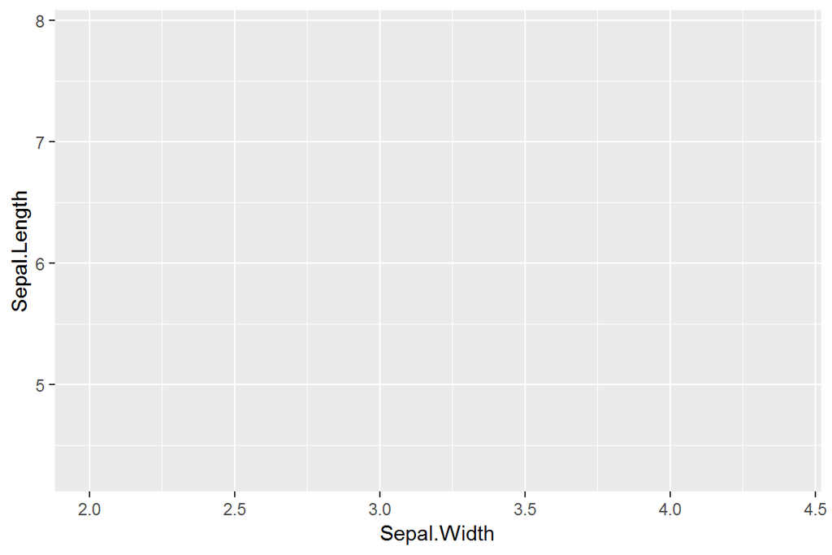

割当を行っただけのグラフ

```r
iris %>% ggplot(aes(x = Sepal.Width, y = Sepal.Length, color = Species))
```

するとなにもプロットされていないワクが表示されましたが、XとYのレンジは指定されています。これは与えられたデータのレンジに合っており、データ割当だけ行った状態で描けるものが描かれています。

次に階層を追加します。散布図なので、点を描く階層を以下のように追加します。

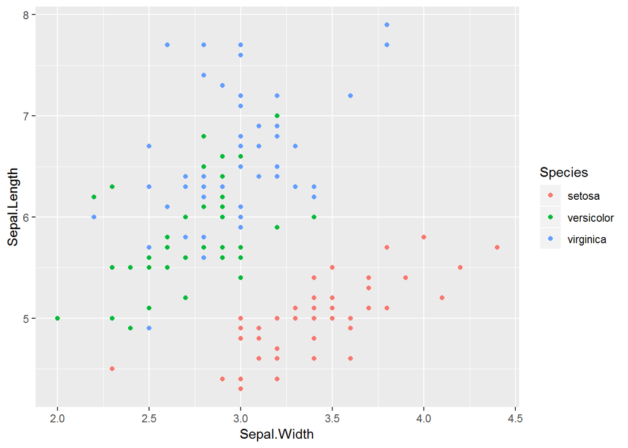

点の階層を追加した

```r
iris %>% ggplot(aes(x = Sepal.Width, y = Sepal.Length, color = Species)) +
  geom_point()
```

オーバラップしていて分かりにくいので種ごとにサブグラフに分けてみましょう。これも階層として以下のように指定できます。

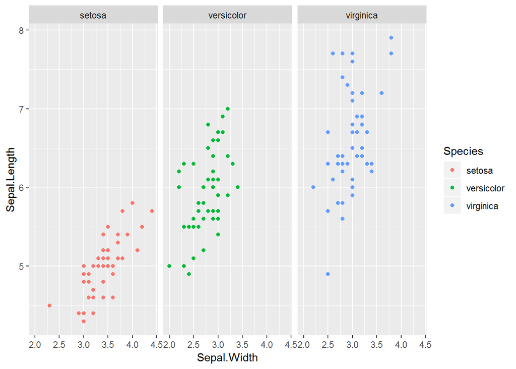

サブグラフの階層を追加した

```r
iris %>% ggplot(aes(x = Sepal.Width, y = Sepal.Length, color = Species)) +
  geom_point() +
  facet_wrap(~ Species)
```

さらに、近似直線も追加してみましょう。

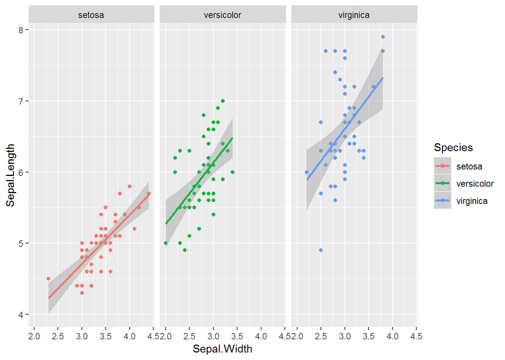

近似直線も追加した

```r
iris %>% ggplot(aes(x = Sepal.Width, y = Sepal.Length, color = Species)) +
  geom_point() +
  geom_smooth(method = "lm") +
  facet_wrap(~ Species)
```

このようにグラフ要素を1つづつ重ねてグラフを作成していきます。

花弁のデータもプロットしたいときは、割当を上書きした階層を追加する方法で書けますが、もっと論理的な方法をデータ整形の回に勉強します。[^4]

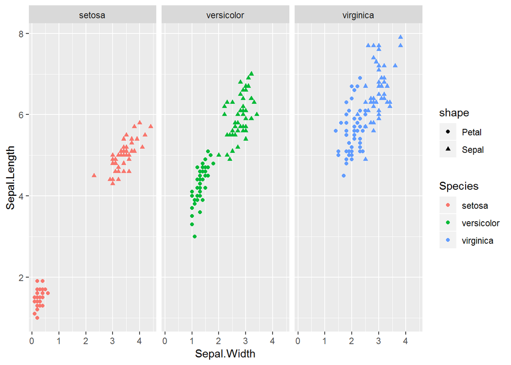

よくない例

```r
iris %>% ggplot(aes(x = Sepal.Width, y = Sepal.Length, color = Species)) +
  geom_point(aes(shape = "Sepal")) +
  geom_point(aes(x = Petal.Width, y = Petal.Length, shape = "Petal")) +
  facet_wrap(~ Species)
```

# 様々なグラフ

Rでは様々なグラフを作ることができ、メニュー[Help -> Cheetsheets -> Data Visualization with ggplot2]から、作成できるグラフの一覧を見ることができます。パッケージを追加すれば3Dグラフなども作れるようになります。

ここでは散布図以外のグラフを、いくつかを実際に描いてみましょう。  
グラフの種類を決めるグラフ要素は、`geom_`から始まる名前の関数を使って作ります。

## 折れ線グラフ

ここではテスト用に、`a`と`b`という2つの独立したランダムデータをもつテーブルデータを用意します。[^5]

```r
data <- tibble(a = rnorm(1000), b = rnorm(1000))
```

折れ線グラフには2種類あり、横軸の順にプロットするには`geom_line()`を、データの並び順にプロットするには`geom_path()`を使います。

- `geom_line()`

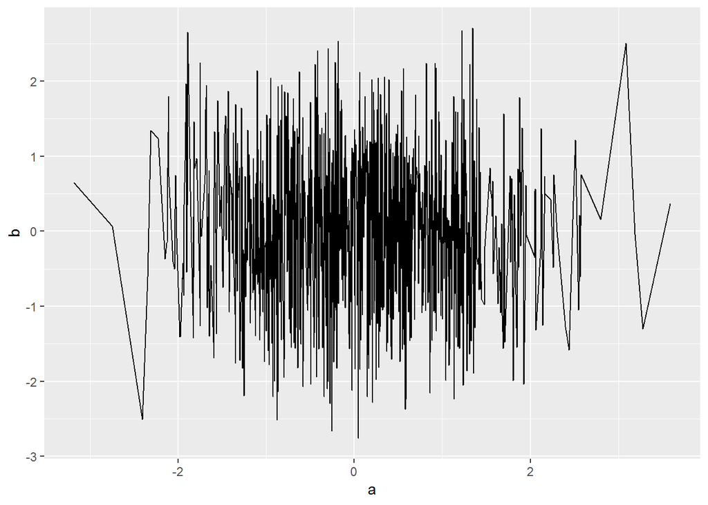

  折れ線グラフ(横軸順)

  ```r
  data %>% ggplot(aes(x = a, y = b)) + geom_line()
  ```

- `geom_path()`

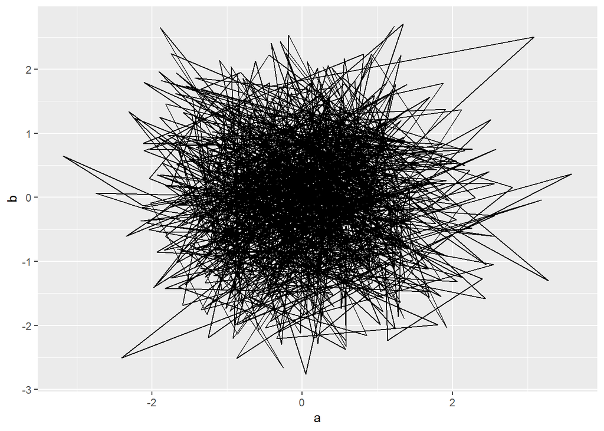

  折れ線グラフ(データ並び順)

  ```r
  data %>% ggplot(aes(x = a, y = b)) + geom_path()
  ```